# Второй этап индивидуального проекта

Операционные системы

Краснова К. Г.

Российский университет дружбы народов, Москва, Россия

21 марта 2025

## Цель работы

Целью данной лабораторной работы является добавление основных данных о себе и создание постов.

## Задание

1. Разместить фотографию владельца сайта.
2. Разместить краткое описание владельца сайта (Biography).
3. Добавить информацию об интересах (Interests).
4. Добавить информацию от образовании (Education).
5. Сделать пост по прошедшей неделе.
6. Добавить пост на тему: Управление версиями. Git.

## Размещение фотографии владельца

Добавляю в папку admin свою фотографию, которая будет в дальнейшем отображаться на сайте (рис. 1).

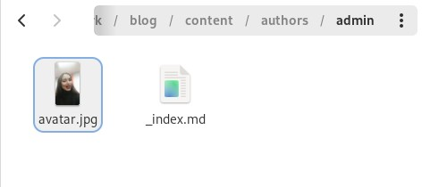

Фотография

## Размещение информации о владельце сайта

Прописываю свое имя (рис. 2).

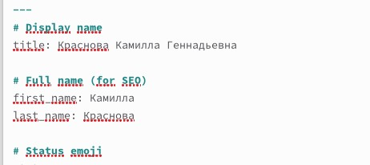

Имя

## Размещение информации о владельце сайта

Пишу кем я являюсь на данный момент и добавляю ссылку на ВУЗ (рис. 3).

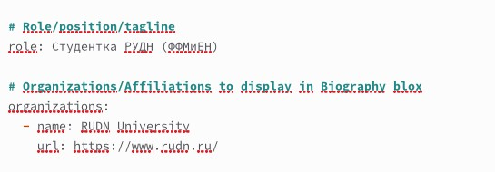

Роль

## Информация об интересах

Добавляю информацию о своих интересах (рис. 4).

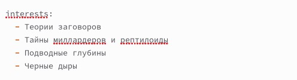

Интересы

## Образование

Прописываю где я обучалась и обучаюсь, вставляю ссылку на место обучения (рис. 5).

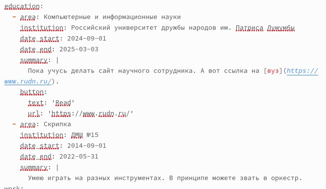

Образование

## Обо мне

В конце добавляю краткую информацию о себе (рис. 6).

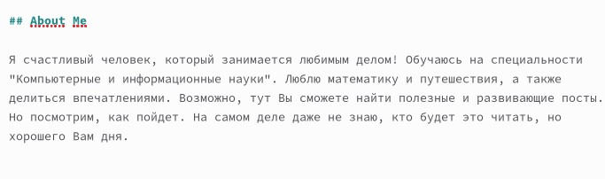

Биография

## Обо мне

В итоге как выглядит теперь моя страничка (рис. 7).

[figure not shown]

Страница сайта

## Пост о прошедшей неделе

Захожу в папку post. Начинаю писать пост о прошедшей неделе (рис. 8).

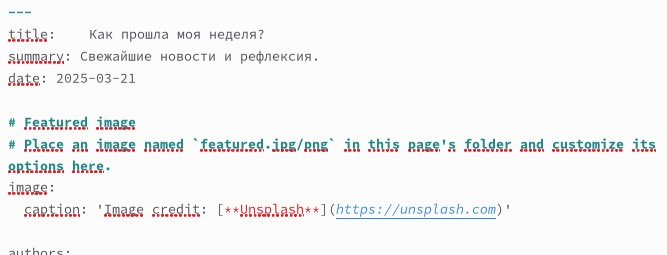

Пост о прошедшей неделе

## Пост о прошедшей неделе

Смотрю, как это выглядит на сайте (рис. 9).

[figure not shown]

Готовый пост

## Пост об управлении версиями git

Начинаю прописывать пост (рис. 10).

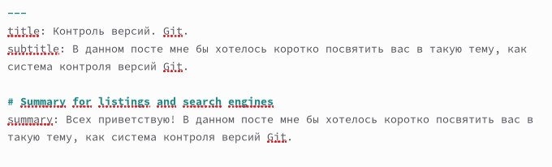

Написание поста

## Пост об управлении версиями git

Уже готовый написанный пост на сайте (рис. 11).

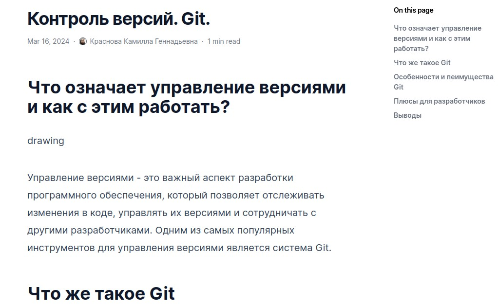

Готовый пост

## Выводы

В ходе выполнения данной лабораторной работы я научилась добавлять основные данные о себе и создавать посты.